# Calibration for iBeacons

Luis P.

05/15/2015

# The beacons

# Calibration - Walk 1

This walk went over the beacons 1-6 and 1 again, for 10s in each of them, with 5 secons to move among beacons.

We load the JSON data measured, and we add the real values of the walk (approximated)

# NEW ATTEMPTS

```
## [1] 1.893306
## [1] 1.323845
```

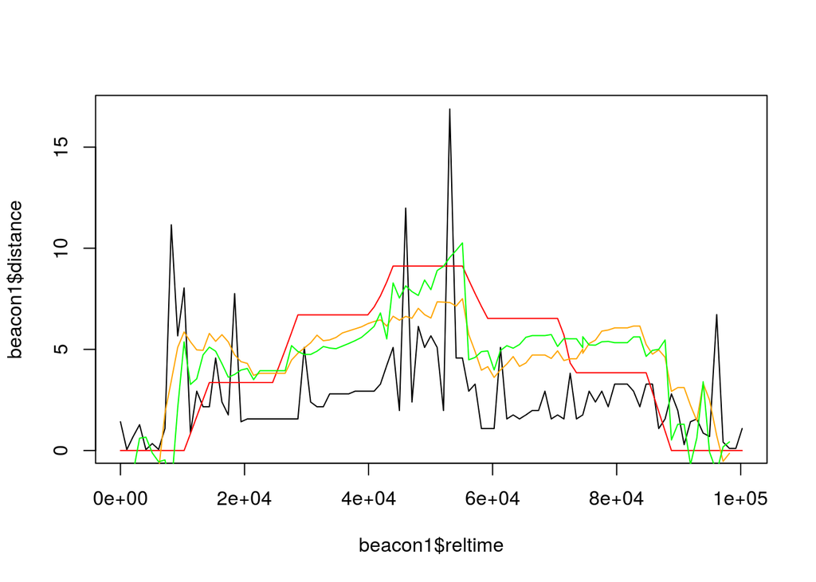

```
## [1] 1.273059
## [1] 1.1491
```

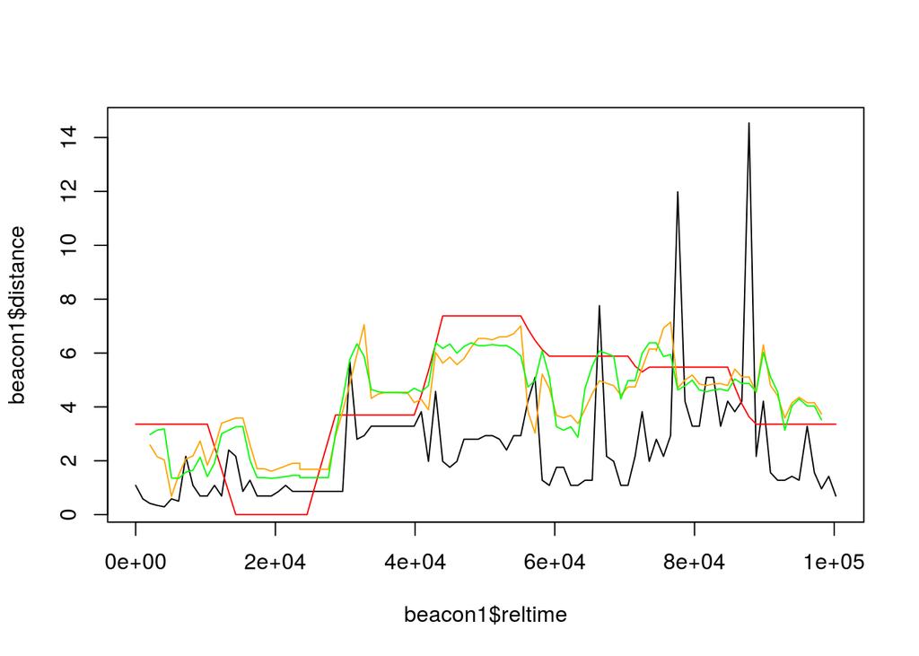

```
## [1] 1.487867
## [1] 1.183006
```

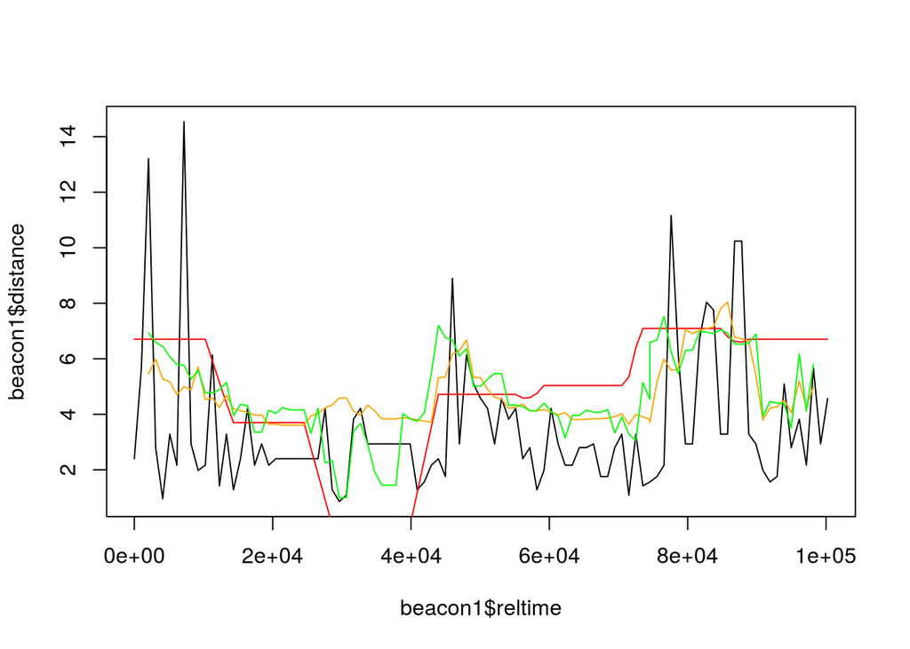

```
## [1] 2.322082
## [1] 1.790549
```

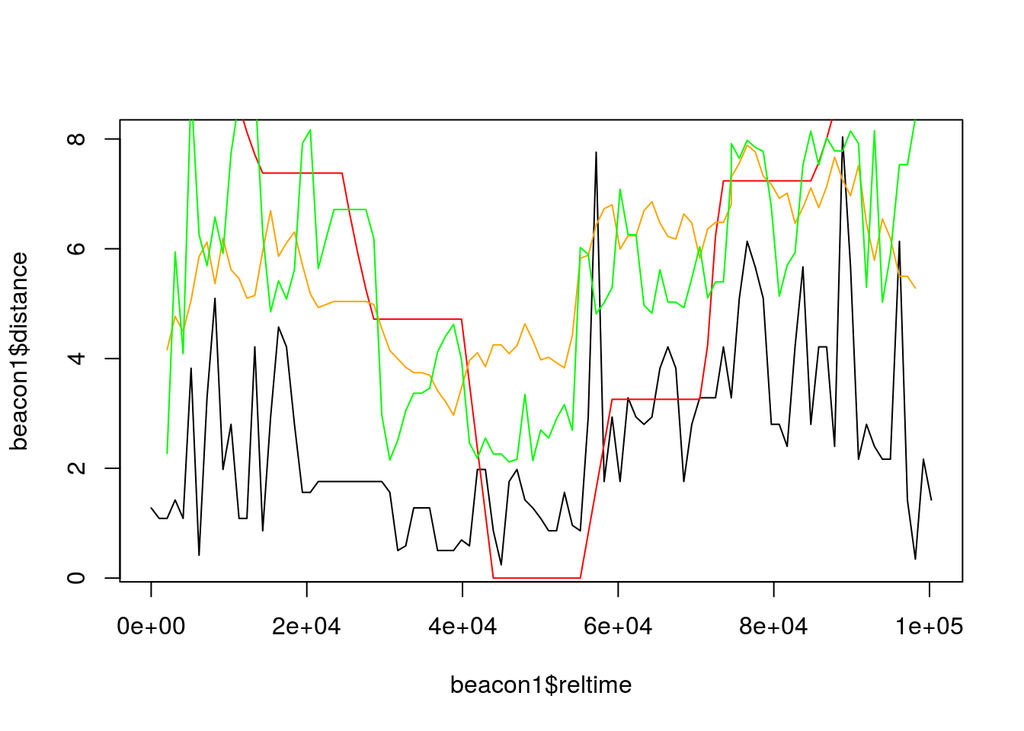

```
## [1] 1.159899
## [1] 0.8231016
```

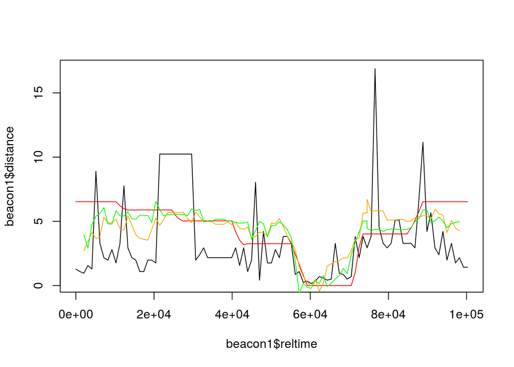

```
## [1] 0.7599648
## [1] 0.6347748
```

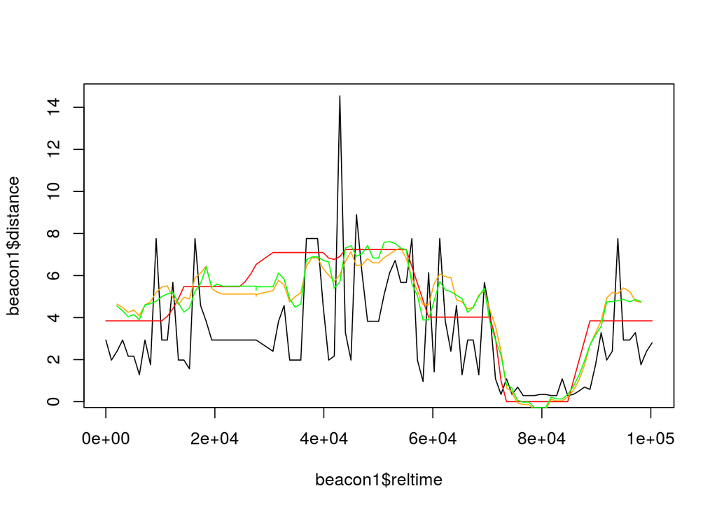

```
##      timestamp    beaconID proximity distance rssi reltime realX realY
## 1 1.431699e+12  2982-17929         2 1.423132  -63       0     0     0
## 2 1.431699e+12  11667-6916         2 1.087574  -61       0     0     0
## 3 1.431699e+12 62375-26168         2 1.278412  -62       0     0     0
## 4 1.431699e+12 33198-27248         2 1.278412  -62       0     0     0
## 5 1.431699e+12 55326-46713         2 2.933973  -70       0     0     0
## 6 1.431699e+12 33875-41478         2 2.399023  -68       0     0     0
##   beaconX beaconY realDist fittedDistLM fittedDistGAM
## 1     0.0     0.0 0.000000           NA            NA
## 2    -2.0     2.7 3.360060           NA            NA
## 3     3.0     5.8 6.529931           NA            NA
## 4     2.0     8.9 9.121952           NA            NA
## 5     3.4     1.8 3.847077           NA            NA
## 6    -2.0     6.4 6.705222           NA            NA
```

```
## [1] 1.314797
```

```
## [1] 0.9139719
```

```
## [1] 1.261697
```

```
## [1] 0.6934259
```

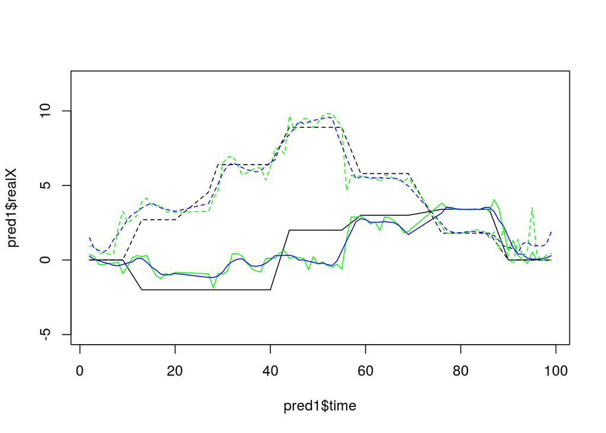

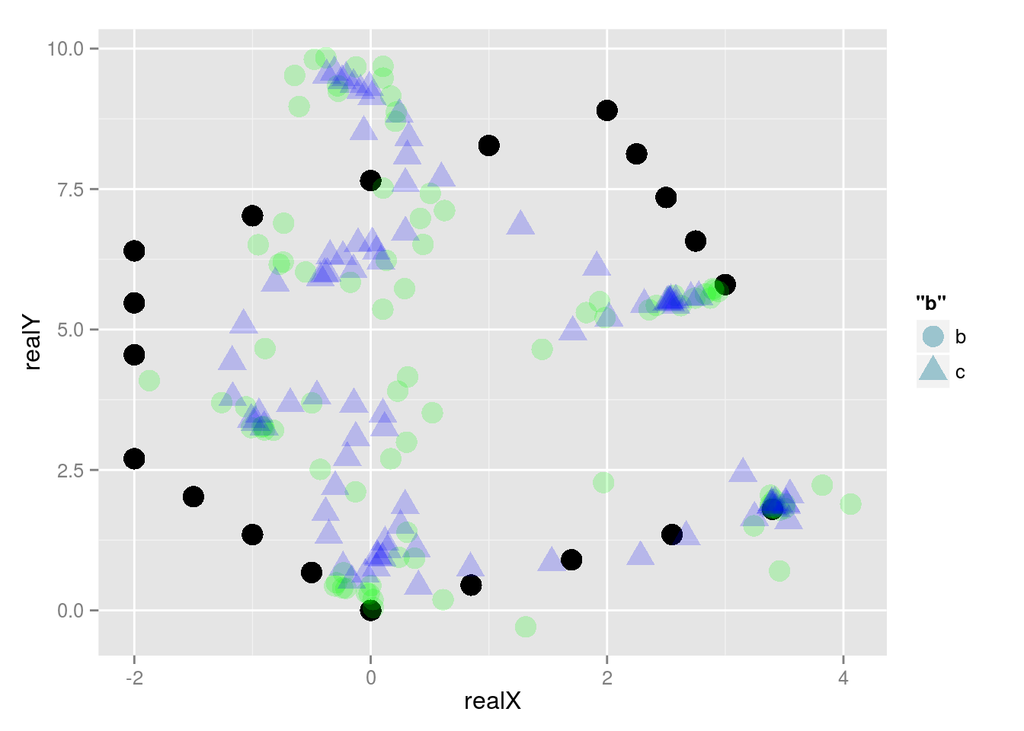

## Test walk (cross pattern)

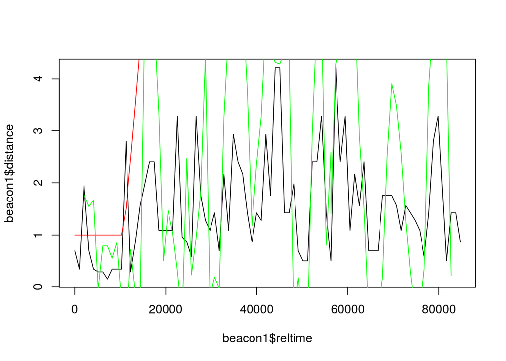

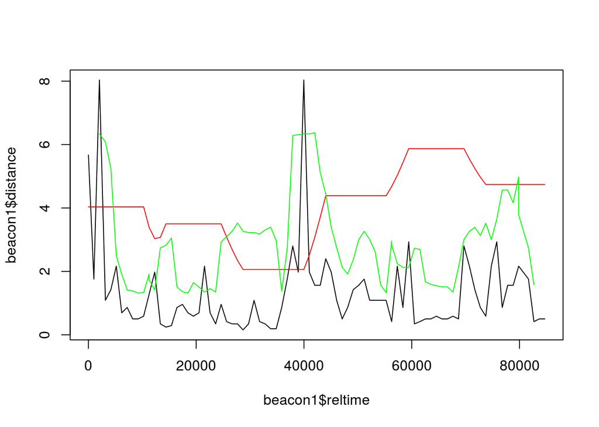

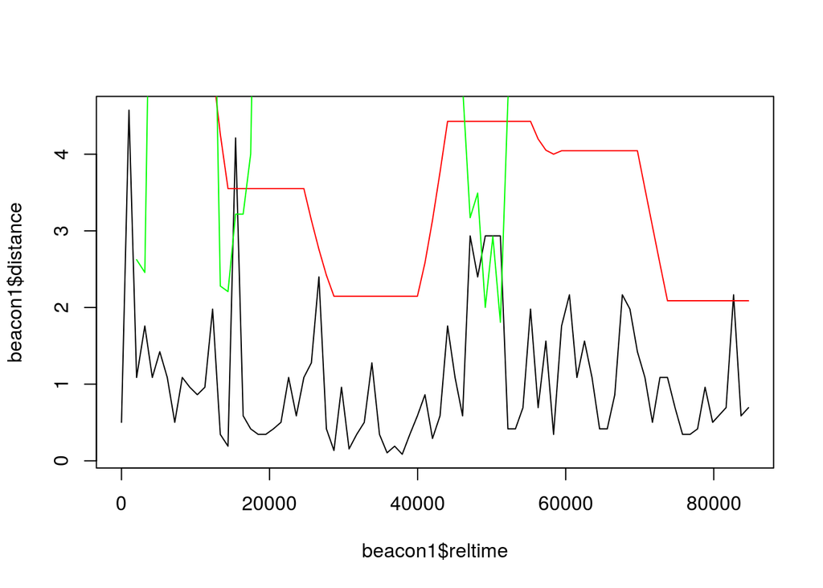

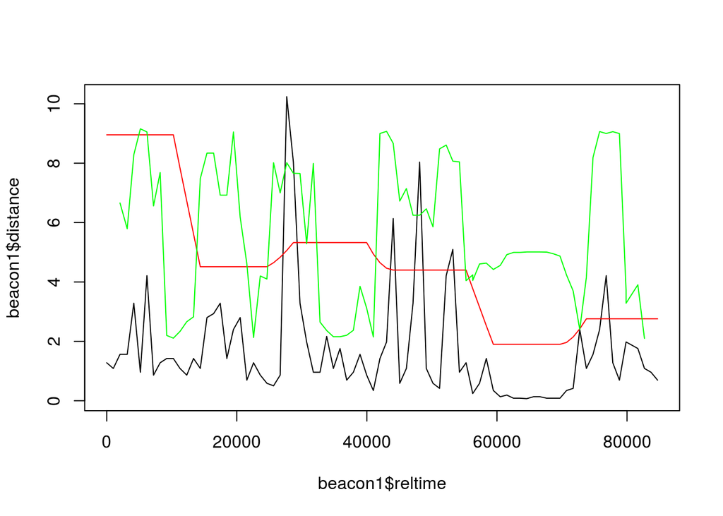

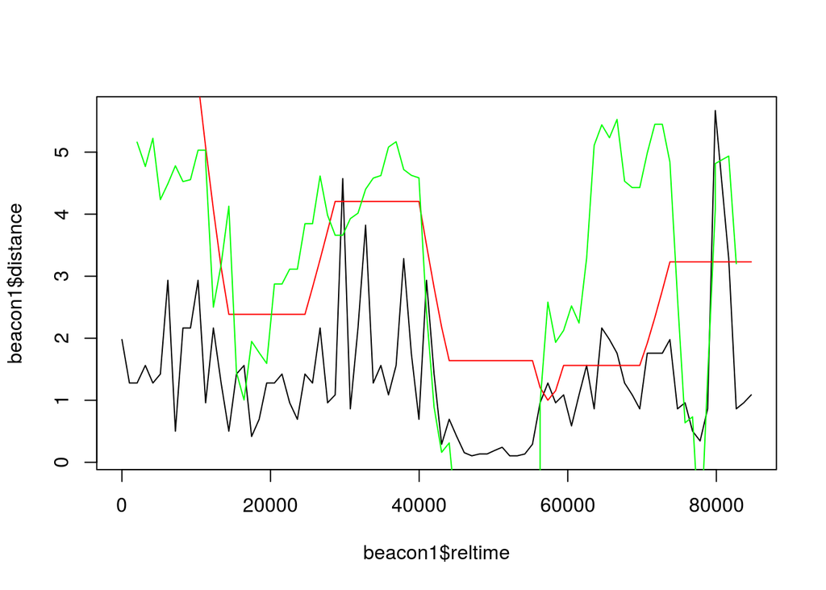

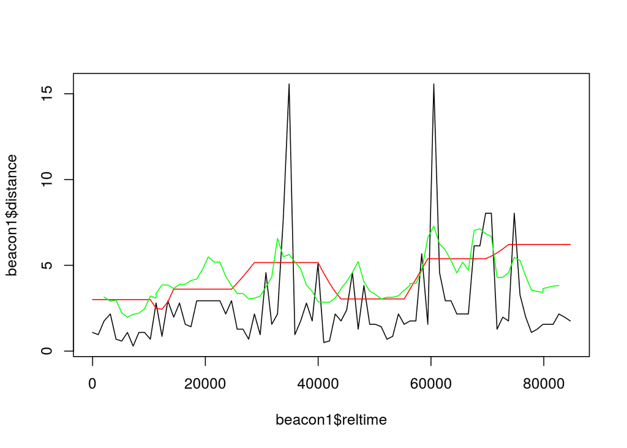

```
## [1] 1.618348
```

```
## [1] 1.007191
```

```
## [1] 1.546002
```

```
## [1] 0.9176686
```

```
## [1] 2.791571
```

```
## [1] 1.847823
```

```
## [1] 2.495148
```

```
## [1] 1.752608
```

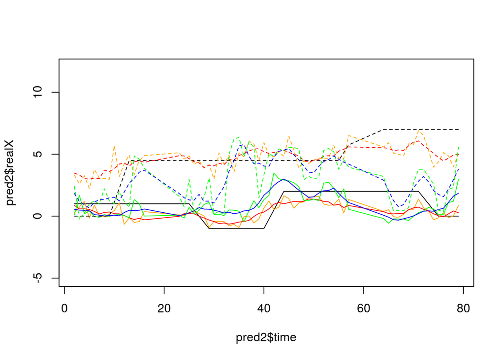

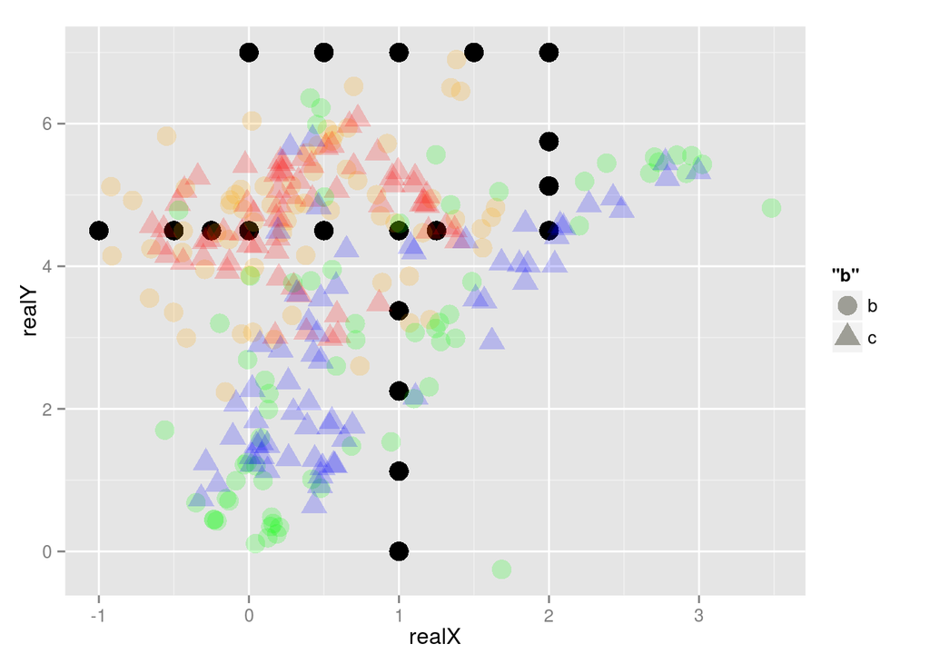

- As we can see, error is huge (2.4m with the GAM-trained trilateration)!
- Smoothing of the predicted coordinates seems to help a bit in every case (2.4m vs. 2.7m)
- And actually, it works better if we use the (smoothed) plain trilateration, not the trilateration trained through GAM in a calibration walk (1.5m vs. 2.4m)!

# OLD ATTEMPTS

## Model 1: per-sample nonlinear trilateration (no training)

```r
#First attempt... non linear model trilateration, not training
pred1 <- data.frame(time=unique(round(df$reltime/1000)),realX=NA,realY=NA,predX=NA,predY=NA)
for(i in unique(round(df$reltime/1000))){

    pred1[i,"realX"] <- unique(df[round(df$reltime/1000)==i,"realX"])[[1]]
    pred1[i,"realY"] <- unique(df[round(df$reltime/1000)==i,"realY"])[[1]]

## Plotting of the original data
#   plot(beacons$beaconX,beacons$beaconY,xlim=c(-10,11),ylim=c(-8,17))
#    subset <- df[round(df/1000)==i,]
#    points(subset$realX,subset$realY, pch="x", cex=2)
#     for(beacon in beacons$beaconID){
#         draw.circle(beacons[beacons$beaconID==beacon,"beaconX"],beacons[beacons$beaconID==beacon,"beaconY"],radius=subset[subset$beaconID==beacon,"distance"],border="blue")
#     }

    # We estimate the position, see http://gis.stackexchange.com/questions/93126/trilateration-algorithm-for-n-amount-of-points-in-r
    subset <- df[round(df$reltime/1000)==i,c("beaconID","distance")]
    data <- merge(subset,beacons)

    #This code does not work?
    #norm_vec <- function(x) sqrt(sum((x[1]-data$beaconX)^2+(x[2]-data$beaconY)^2))-sum(data$distance)
    #fit <- nlm(norm_vec,c(mean(data$beaconX),mean(data$beaconY)))
    #fit$code

    norm_vec <- function(x) sum(((sqrt((x[1]-data$beaconX)^2+(x[2]-data$beaconY)^2) - data$distance)^2)/(1+data$distance^2))
    fit <- nlm(norm_vec,c(mean(data$beaconX),mean(data$beaconY)))

    pred1[i,"predX"] <- fit$estimate[1]
    pred1[i,"predY"] <- fit$estimate[2]

## Plotting the predicted points
#   points(fit$estimate[1],fit$estimate[2], pch="o", cex=2)
#   cat ("Press [enter] to continue")
#   line <- readline()
}

pred1 <- pred1[complete.cases(pred1),]
corX <- cor(pred1$realX,pred1$predX)
print(paste("Rsquared X=",corX^2,sep=""))
```

```
## [1] "Rsquared X=0.373407876797344"
```

```r
corY <- cor(pred1$realY,pred1$predY)
print(paste("Rsquared Y=",corY^2,sep=""))
```

```
## [1] "Rsquared Y=0.647036725107707"
```

```r
pred1$residual <- sqrt((pred1$realX-pred1$predX)^2 + (pred1$realY-pred1$predY)^2)
print(paste("Overall RMSE=",sqrt(var(pred1$residual, na.rm=T)),sep=""))
```

```
## [1] "Overall RMSE=0.941690807675846"
```

```r
distanceError <- sqrt((pred1$predX - pred1$realX)^2 + (pred1$predY - pred1$realY)^2)
mean(distanceError)
```

```
## [1] 2.470966
```

```r
sd(distanceError)
```

```
## [1] 0.9416908
```

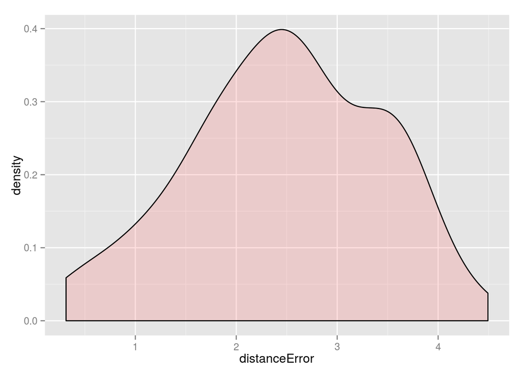

```r
error <- as.data.frame(distanceError)
ggplot(error, aes(x=distanceError)) + geom_density(alpha=.2, fill="#FF6666")
```

## Model 2: generalized linear model training

```r
# Second attempt training with generalized linear model
# We reformat our data to have more columns
pred2 <- data.frame(time=unique(round(df$reltime/1000)),realX=NA,realY=NA)
for(t in pred2$time){
    pred2[pred2$time==t,"realX"] <- unique(df[round(df$reltime/1000)==t,"realX"])[[1]]
    pred2[pred2$time==t,"realY"] <- unique(df[round(df$reltime/1000)==t,"realY"])[[1]]
}
for(beacon in beacons$beaconID){
    label = beacons[beacons$beaconID==beacon,"beaconNr"];
    # We create the field distance
    pred2[,paste("distance",label,sep="")] <- NA
    # We go though the time values and fill in the data
    for(t in pred2$time){
        pred2[pred2$time==t,paste("distance",label,sep="")] <- df[round(df$reltime/1000)==t & df$beaconID==beacon,"distance"][1]
    }

    # We create the field rssi
    pred2[,paste("rssi",label,sep="")] <- NA
    # We go though the time values and fill in the data
    for(t in pred2$time){
        pred2[pred2$time==t,paste("rssi",label,sep="")] <- df[round(df$reltime/1000)==t & df$beaconID==beacon,"rssi"][1]
    }

    # We create the field proximity
    pred2[,paste("proximity",label,sep="")] <- NA
    # We go though the time values and fill in the data
    for(t in pred2$time){
        pred2[pred2$time==t,paste("proximity",label,sep="")] <- df[round(df$reltime/1000)==t & df$beaconID==beacon,"proximity"][1]
    }

}

fitlm <- lm(cbind(realX,realY) ~ . - time, data=pred2)
summary(fitlm)
```

```
## Response realX :
##
## Call:
## lm(formula = realX ~ (time + distance1 + rssi1 + proximity1 +
##     distance2 + rssi2 + proximity2 + distance3 + rssi3 + proximity3 +
##     distance4 + rssi4 + proximity4 + distance5 + rssi5 + proximity5 +
##     distance6 + rssi6 + proximity6) - time, data = pred2)
##
## Residuals:
##     Min      1Q  Median      3Q     Max
## -2.9193 -0.6520 -0.1379  0.7997  2.5710
##
## Coefficients:
##             Estimate Std. Error t value Pr(>|t|)
## (Intercept) 15.49943    9.68051   1.601  0.11340
## distance1    0.14892    0.10510   1.417  0.16051
## rssi1        0.09500    0.05420   1.753  0.08357 .
## proximity1   0.90107    0.52628   1.712  0.09084 .
## distance2   -0.37163    0.15372  -2.418  0.01796 *
## rssi2       -0.29887    0.06280  -4.759 8.77e-06 ***
## proximity2  -1.90794    0.48500  -3.934  0.00018 ***
## distance3   -0.01428    0.17547  -0.081  0.93534
## rssi3       -0.01805    0.09224  -0.196  0.84538
## proximity3  -0.30920    0.45960  -0.673  0.50309
## distance4   -0.30356    0.26399  -1.150  0.25370
## rssi4       -0.14490    0.07234  -2.003  0.04866 *
## proximity4  -0.36986    0.50569  -0.731  0.46673
## distance5    0.33579    0.11900   2.822  0.00605 **
## rssi5        0.33379    0.05844   5.711 1.95e-07 ***
## proximity5   2.13757    0.43326   4.934 4.47e-06 ***
## distance6    0.58374    0.14039   4.158 8.17e-05 ***
## rssi6        0.29644    0.05960   4.974 3.82e-06 ***
## proximity6   0.51251    0.46948   1.092  0.27835
## ---
## Signif. codes:  0 '***' 0.001 '**' 0.01 '*' 0.05 '.' 0.1 ' ' 1
##
## Residual standard error: 1.201 on 78 degrees of freedom
##   (2 observations deleted due to missingness)
## Multiple R-squared:  0.7164, Adjusted R-squared:  0.651
## F-statistic: 10.95 on 18 and 78 DF,  p-value: 1.07e-14
```

[output cut: 27 more lines]

```
## rssi4        0.15223    0.10408   1.463   0.1476
## proximity4   0.29884    0.72758   0.411   0.6824
## distance5    0.95929    0.17121   5.603 3.05e-07 ***
## rssi5        0.50708    0.08409   6.030 5.13e-08 ***
## proximity5   1.33034    0.62336   2.134   0.0360 *
## distance6   -0.22092    0.20198  -1.094   0.2774
## rssi6       -0.12899    0.08575  -1.504   0.1366
## proximity6   0.72898    0.67548   1.079   0.2838
## ---
## Signif. codes:  0 '***' 0.001 '**' 0.01 '*' 0.05 '.' 0.1 ' ' 1
##
## Residual standard error: 1.728 on 78 degrees of freedom
##   (2 observations deleted due to missingness)
## Multiple R-squared:  0.7561, Adjusted R-squared:  0.6998
## F-statistic: 13.43 on 18 and 78 DF,  p-value: < 2.2e-16
```

```r
#predictions <- predict(fitlm, data.frame=pred2[,-c("realX","realY")])
#We plot the predictions
# count=0
# for(i in pred2$time){
#     count <- count+1
#     plot(beacons$beaconX,beacons$beaconY,xlim=c(-10,11),ylim=c(-8,17))
#
#     subset <- df[round(df$reltime/1000)==i,]
#     points(subset$realX,subset$realY, pch="x", cex=2)
#     for(beacon in beacons$beaconID){
#         draw.circle(beacons[beacons$beaconID==beacon,"beaconX"],beacons[beacons$beaconID==beacon,"beaconY"],radius=subset[subset$beaconID==beacon,"distance"],border="blue")
#     }
#     points(predictions[count,"realX"],predictions[count,"realY"], pch="o", cex=2)
#     cat ("Press [enter] to continue")
#     line <- readline()
# }

predictions <- predict(fitlm,newdata=pred2)
pred2$predX <- predictions[,1]
pred2$predY <- predictions[,2]
pred2 <- pred2[complete.cases(pred2),]
distanceError <- sqrt((pred2$predX - pred2$realX)^2 + (pred2$predY - pred2$realY)^2)
mean(distanceError)
```

```
## [1] 1.663829
```

```r
sd(distanceError)
```

```
## [1] 0.8958517
```

As we see from the R-squared, the GLM training performs a bit better (in the training dataset!)

## Model 3: linear model based on time-smoothing of distances to beacon only

```r
# TODO: Third attempt training with smoothing the distances only
pred3 <- pred2

for (i in 1:6){
    column <- pred3[,paste("distance",i,sep="")]

    #We do filtering before smoothing the signal, taking into account the size of the room (9m longer diameter)
    column[column>ROOMSIZE]<-ROOMSIZE

    ld <- loess(column~time,pred3,span=0.15)
    pred3[,paste("loessdistance",i,sep="")] <- predict(ld,pred3)
#    plot(pred3$time,pred3[,paste("distance",i,sep="")], type="l")
#    lines(pred3$time,pred3[,paste("loessdistance",i,sep="")],col=3)
}

fitloesslm <- lm(cbind(realX,realY) ~ loessdistance1+loessdistance2+loessdistance3+loessdistance4+loessdistance5+loessdistance6, data=pred3)
summary(fitloesslm)
```

```
## Response realX :
##
## Call:
## lm(formula = realX ~ loessdistance1 + loessdistance2 + loessdistance3 +
##     loessdistance4 + loessdistance5 + loessdistance6, data = pred3)
##
## Residuals:
##     Min      1Q  Median      3Q     Max
## -3.7654 -1.0538  0.2776  1.0896  1.9282
##
## Coefficients:
##                Estimate Std. Error t value Pr(>|t|)
## (Intercept)    -1.43996    1.29544  -1.112  0.26929
## loessdistance1  0.38858    0.17192   2.260  0.02621 *
## loessdistance2  0.23470    0.14579   1.610  0.11093
## loessdistance3  0.18299    0.16991   1.077  0.28435
## loessdistance4  0.75849    0.19158   3.959  0.00015 ***
## loessdistance5 -0.38937    0.08409  -4.631 1.22e-05 ***
## loessdistance6 -0.23066    0.20345  -1.134  0.25992
## ---
## Signif. codes:  0 '***' 0.001 '**' 0.01 '*' 0.05 '.' 0.1 ' ' 1
##
## Residual standard error: 1.437 on 90 degrees of freedom
## Multiple R-squared:  0.5317, Adjusted R-squared:  0.5005
## F-statistic: 17.03 on 6 and 90 DF,  p-value: 4.715e-13
##
##
## Response realY :
##
## Call:
## lm(formula = realY ~ loessdistance1 + loessdistance2 + loessdistance3 +
##     loessdistance4 + loessdistance5 + loessdistance6, data = pred3)
##
## Residuals:
##     Min      1Q  Median      3Q     Max
## -3.8145 -1.0494  0.0284  1.5237  2.8601
##
## Coefficients:
##                Estimate Std. Error t value Pr(>|t|)
## (Intercept)      1.5494     1.6036   0.966 0.336529
## loessdistance1   0.5444     0.2128   2.558 0.012197 *
## loessdistance2   1.4099     0.1805   7.812 9.91e-12 ***
## loessdistance3  -0.7986     0.2103  -3.797 0.000266 ***
## loessdistance4  -0.7363     0.2371  -3.105 0.002544 **
## loessdistance5  -0.1079     0.1041  -1.037 0.302699
## loessdistance6   0.7492     0.2518   2.975 0.003764 **
## ---
## Signif. codes:  0 '***' 0.001 '**' 0.01 '*' 0.05 '.' 0.1 ' ' 1
##
## Residual standard error: 1.779 on 90 degrees of freedom
## Multiple R-squared:  0.7019, Adjusted R-squared:  0.682
## F-statistic: 35.31 on 6 and 90 DF,  p-value: < 2.2e-16
```

… and a similar variant taking into acount the interactions

```r
fitloesslm2 <- lm(cbind(realX,realY) ~ loessdistance1*loessdistance2*loessdistance3*loessdistance4*loessdistance5*loessdistance6, data=pred3)
summary(fitloesslm2)
```

```
## Response realX :
##
## Call:
## lm(formula = realX ~ loessdistance1 * loessdistance2 * loessdistance3 *
##     loessdistance4 * loessdistance5 * loessdistance6, data = pred3)
##
## Residuals:
##      Min       1Q   Median       3Q      Max
## -0.71239 -0.08569 -0.00126  0.09255  0.38263
##
## Coefficients:
##                                                                                             Estimate
## (Intercept)                                                                                73.051017
## loessdistance1                                                                            -11.054480
## loessdistance2                                                                             55.613562
## loessdistance3                                                                            -33.993267
## loessdistance4                                                                            -20.257579
## loessdistance5                                                                            -40.715330
## loessdistance6                                                                            -60.947843
## loessdistance1:loessdistance2                                                             -15.184277
## loessdistance1:loessdistance3                                                               6.082173
## loessdistance2:loessdistance3                                                              -6.921905
## loessdistance1:loessdistance4                                                               6.563559
## loessdistance2:loessdistance4                                                             -26.626614
## loessdistance3:loessdistance4                                                              14.093366
## loessdistance1:loessdistance5                                                               5.233232
## loessdistance2:loessdistance5                                                             -13.708937
## loessdistance3:loessdistance5                                                              19.147422
## loessdistance4:loessdistance5                                                              15.647435
## loessdistance1:loessdistance6                                                              19.348575
## loessdistance2:loessdistance6                                                              -2.134478
## loessdistance3:loessdistance6                                                              19.821417
## loessdistance4:loessdistance6                                                              18.483745
## loessdistance5:loessdistance6                                                              20.312981
## loessdistance1:loessdistance2:loessdistance3                                                1.200281
## loessdistance1:loessdistance2:loessdistance4                                               10.190926
## loessdistance1:loessdistance3:loessdistance4                                               -4.882062
## loessdistance2:loessdistance3:loessdistance4                                                2.022414
## loessdistance1:loessdistance2:loessdistance5                                                2.878752
## loessdistance1:loessdistance3:loessdistance5                                               -1.664478
```

[output cut: 631 more lines]

```
## loessdistance2:loessdistance4:loessdistance5:loessdistance6                               *
## loessdistance3:loessdistance4:loessdistance5:loessdistance6                               **
## loessdistance1:loessdistance2:loessdistance3:loessdistance4:loessdistance5                .
## loessdistance1:loessdistance2:loessdistance3:loessdistance4:loessdistance6                *
## loessdistance1:loessdistance2:loessdistance3:loessdistance5:loessdistance6                .
## loessdistance1:loessdistance2:loessdistance4:loessdistance5:loessdistance6                **
## loessdistance1:loessdistance3:loessdistance4:loessdistance5:loessdistance6                **
## loessdistance2:loessdistance3:loessdistance4:loessdistance5:loessdistance6                *
## loessdistance1:loessdistance2:loessdistance3:loessdistance4:loessdistance5:loessdistance6 *
## ---
## Signif. codes:  0 '***' 0.001 '**' 0.01 '*' 0.05 '.' 0.1 ' ' 1
##
## Residual standard error: 0.4504 on 33 degrees of freedom
## Multiple R-squared:  0.993,  Adjusted R-squared:  0.9796
## F-statistic: 74.22 on 63 and 33 DF,  p-value: < 2.2e-16
```

```r
predictions <- predict(fitloesslm2, newdata=pred3)
# #We plot the predictions
# count=0
# for(i in pred3$time){
#     count <- count+1
#     plot(beacons$beaconX,beacons$beaconY,xlim=c(-10,11),ylim=c(-8,17))
#
#     subset <- df[round(df$reltime/1000)==i,]
#     points(subset$realX,subset$realY, pch="x", cex=2)
#     for(beacon in beacons$beaconID){
#         draw.circle(beacons[beacons$beaconID==beacon,"beaconX"],beacons[beacons$beaconID==beacon,"beaconY"],radius=subset[subset$beaconID==beacon,"distance"],border="blue")
#     }
#     points(predictions[count,"realX"],predictions[count,"realY"], pch="o", cex=2)
#     cat ("Press [enter] to continue")
#     line <- readline()
# }

pred3$predX <- predictions[,1]
pred3$predY <- predictions[,2]

distanceError <- sqrt((pred3$predX - pred3$realX)^2 + (pred3$predY - pred3$realY)^2)
mean(distanceError)
```

```
## [1] 0.2485048
```

```r
sd(distanceError)
```

```
## [1] 0.180044
```

We see it is **REALLY** close to the mark at all times, within 0.5/1 meter of the real position. But… is it overfitting (to a walk around the walls)? Let’s try different walks:

## Model 4: per-sample nonlinear trilateration with smoothing

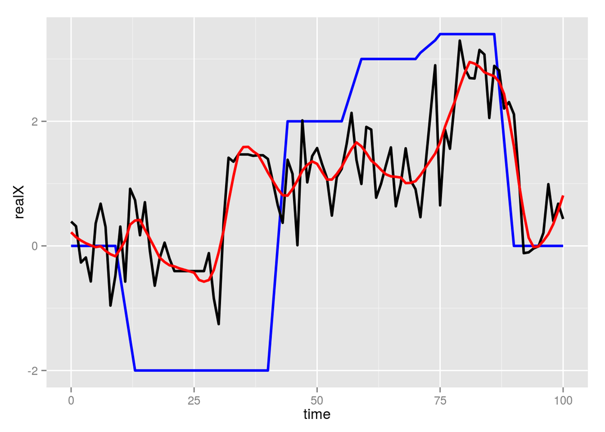

```r
#First attempt... non linear model trilateration, not training
pred4 <- data.frame(time=unique(round(df$reltime/1000)),realX=NA,realY=NA,predX=NA,predY=NA)
for(i in unique(round(df$reltime/1000))){

    pred4[i,"realX"] <- unique(df[round(df$reltime/1000)==i,"realX"])[[1]]
    pred4[i,"realY"] <- unique(df[round(df$reltime/1000)==i,"realY"])[[1]]

## Plotting of the original data
#   plot(beacons$beaconX,beacons$beaconY,xlim=c(-10,11),ylim=c(-8,17))
#    subset <- df[round(df/1000)==i,]
#    points(subset$realX,subset$realY, pch="x", cex=2)
#     for(beacon in beacons$beaconID){
#         draw.circle(beacons[beacons$beaconID==beacon,"beaconX"],beacons[beacons$beaconID==beacon,"beaconY"],radius=subset[subset$beaconID==beacon,"distance"],border="blue")
#     }

    # We estimate the position, see http://gis.stackexchange.com/questions/93126/trilateration-algorithm-for-n-amount-of-points-in-r
    subset <- df[round(df$reltime/1000)==i,c("beaconID","distance")]
    data <- merge(subset,beacons)

    #This code does not work?
    #norm_vec <- function(x) sqrt(sum((x[1]-data$beaconX)^2+(x[2]-data$beaconY)^2))-sum(data$distance)
    #fit <- nlm(norm_vec,c(mean(data$beaconX),mean(data$beaconY)))
    #fit$code

    norm_vec <- function(x) sum(((sqrt((x[1]-data$beaconX)^2+(x[2]-data$beaconY)^2) - data$distance)^2)/(1+data$distance^2))
    fit <- nlm(norm_vec,c(mean(data$beaconX),mean(data$beaconY)))

    pred4[i,"predX"] <- fit$estimate[1]
    pred4[i,"predY"] <- fit$estimate[2]

## Plotting the predicted points
#   points(fit$estimate[1],fit$estimate[2], pch="o", cex=2)
#   cat ("Press [enter] to continue")
#   line <- readline()
}

pred4 <- pred4[complete.cases(pred4),]

smoothfitX <- loess(predX~time,pred4,span=0.15)
smoothfitY <- loess(predY~time,pred4,span=0.15)
pred4$smpredX <- predict(smoothfitX,pred4)
pred4$smpredY <- predict(smoothfitY,pred4)

ggplot(pred4, aes(x = time, y = realX)) + geom_line(col="blue",size=1) + geom_line(data=pred4, aes(x=time,y=predX),col="black",size=1) + geom_line(data=pred4, aes(x=time,y=smpredX),col="red",size=1)
```

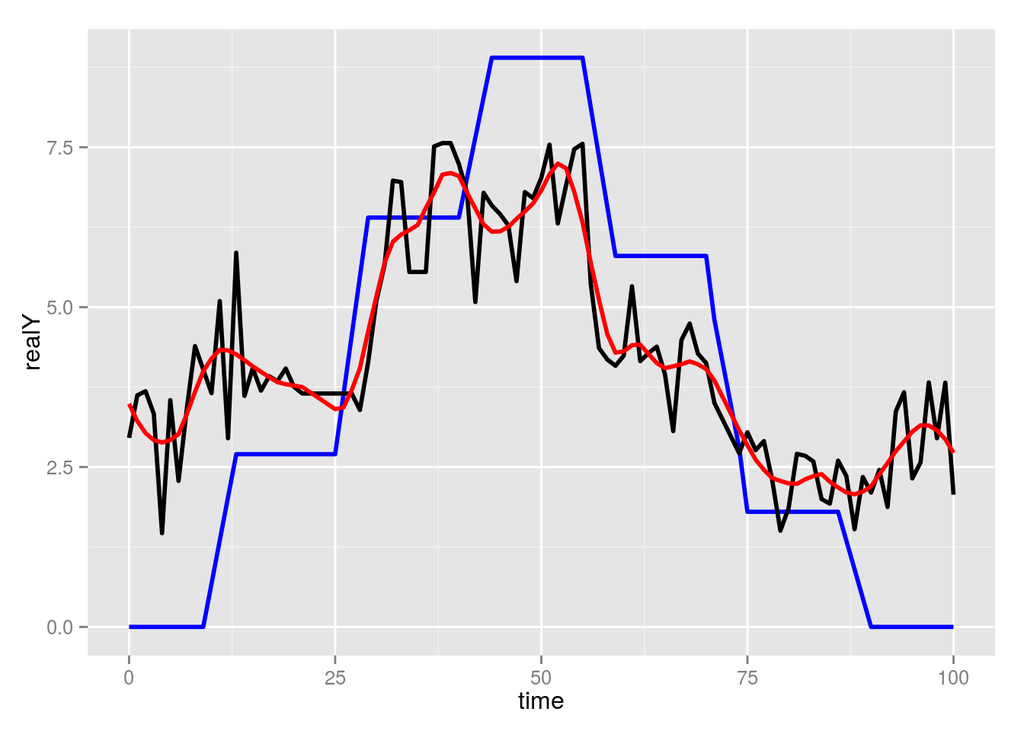

```r
ggplot(pred4, aes(x = time, y = realY)) + geom_line(col="blue",size=1) + geom_line(data=pred4, aes(x=time,y=predY),col="black",size=1) + geom_line(data=pred4, aes(x=time,y=smpredY),col="red",size=1)
```

```r
corX <- cor(pred4$realX,pred4$predX)
print(paste("Rsquared X=",corX^2,sep=""))
```

```
## [1] "Rsquared X=0.373407876797344"
```

```r
corY <- cor(pred4$realY,pred4$predY)
print(paste("Rsquared Y=",corY^2,sep=""))
```

```
## [1] "Rsquared Y=0.647036725107707"
```

```r
pred4$residual <- sqrt((pred4$realX-pred4$predX)^2 + (pred4$realY-pred4$predY)^2)
print(paste("Overall RMSE=",sqrt(var(pred4$residual, na.rm=T)),sep=""))
```

```
## [1] "Overall RMSE=0.941690807675846"
```

```r
distanceError <- sqrt((pred4$predX - pred4$realX)^2 + (pred4$predY - pred4$realY)^2)
mean(distanceError)
```

```
## [1] 2.470966
```

```r
sd(distanceError)
```

```
## [1] 0.9416908
```

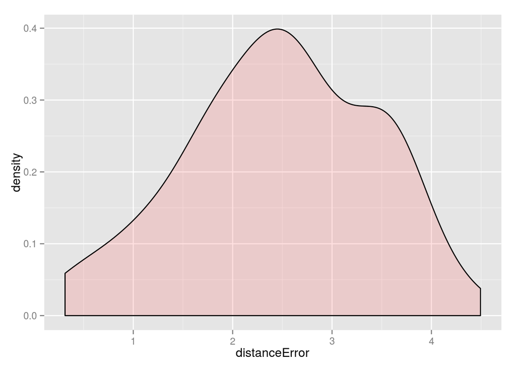

```r
error <- as.data.frame(distanceError)
ggplot(error, aes(x=distanceError)) + geom_density(alpha=.2, fill="#FF6666")
```

## Model 5: per-sample nonlinear trilateration with smoothing BEFORE

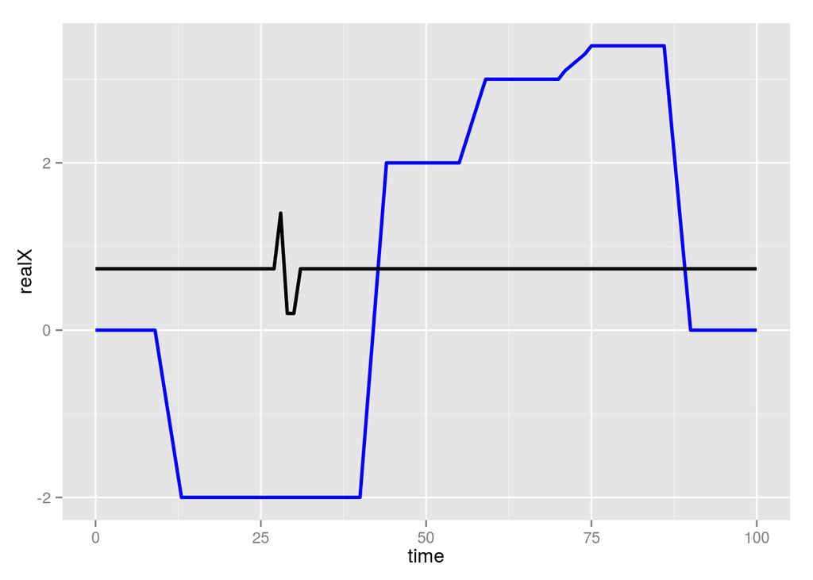

```r
####### REVIEW!!!!!!!!!!!!!

# We smooth the initial distance signal for each beacon
dfsmooth <- data.frame()
for(i in beacons$beaconID){

    subset <- df[df$beaconID==i,]

    #p <- ggplot(subset, aes(x=reltime,y=distance))+geom_line(col="blue",size=1)

    smoothfit <- loess(distance~reltime,subset,span=0.15)
    subset$newdistance <- predict(smoothfit,subset)

    #print(p + geom_line(data=subset, aes(x=reltime,y=newdistance), col="red",size=1))

    #print("more?")
    #line <- readline()
    if(nrow(dfsmooth)==0) dfsmooth <- subset
    else dfsmooth <- rbind(dfsmooth,subset)
}


#First attempt... non linear model trilateration, not training
pred4 <- data.frame(time=unique(round(dfsmooth$reltime/1000)),realX=NA,realY=NA,predX=NA,predY=NA)
for(i in unique(round(dfsmooth$reltime/1000))){

    pred4[i,"realX"] <- unique(dfsmooth[round(dfsmooth$reltime/1000)==i,"realX"])[[1]]
    pred4[i,"realY"] <- unique(dfsmooth[round(dfsmooth$reltime/1000)==i,"realY"])[[1]]

## Plotting of the original data
#   plot(beacons$beaconX,beacons$beaconY,xlim=c(-10,11),ylim=c(-8,17))
#    subset <- df[round(df/1000)==i,]
#    points(subset$realX,subset$realY, pch="x", cex=2)
#     for(beacon in beacons$beaconID){
#         draw.circle(beacons[beacons$beaconID==beacon,"beaconX"],beacons[beacons$beaconID==beacon,"beaconY"],radius=subset[subset$beaconID==beacon,"distance"],border="blue")
#     }

    # We estimate the position, see http://gis.stackexchange.com/questions/93126/trilateration-algorithm-for-n-amount-of-points-in-r
    subset <- dfsmooth[round(dfsmooth$reltime/1000)==i,c("beaconID","distance")]
    data <- merge(subset,beacons)

    #This code does not work?
    #norm_vec <- function(x) sqrt(sum((x[1]-data$beaconX)^2+(x[2]-data$beaconY)^2))-sum(data$distance)
    #fit <- nlm(norm_vec,c(mean(data$beaconX),mean(data$beaconY)))
    #fit$code

    norm_vec <- function(x) sum(((sqrt((x[1]-data$beaconX)^2+(x[2]-data$beaconY)^2) - data$distance)^2)/(1+data$newdistance^2))
    fit <- nlm(norm_vec,c(mean(data$beaconX),mean(data$beaconY)))

    pred4[i,"predX"] <- fit$estimate[1]
    pred4[i,"predY"] <- fit$estimate[2]

## Plotting the predicted points
#   points(fit$estimate[1],fit$estimate[2], pch="o", cex=2)
#   cat ("Press [enter] to continue")
#   line <- readline()
}

pred4 <- pred4[complete.cases(pred4),]


ggplot(pred4, aes(x = time, y = realX)) + geom_line(col="blue",size=1) + geom_line(data=pred4, aes(x=time,y=predX),col="black",size=1)
```

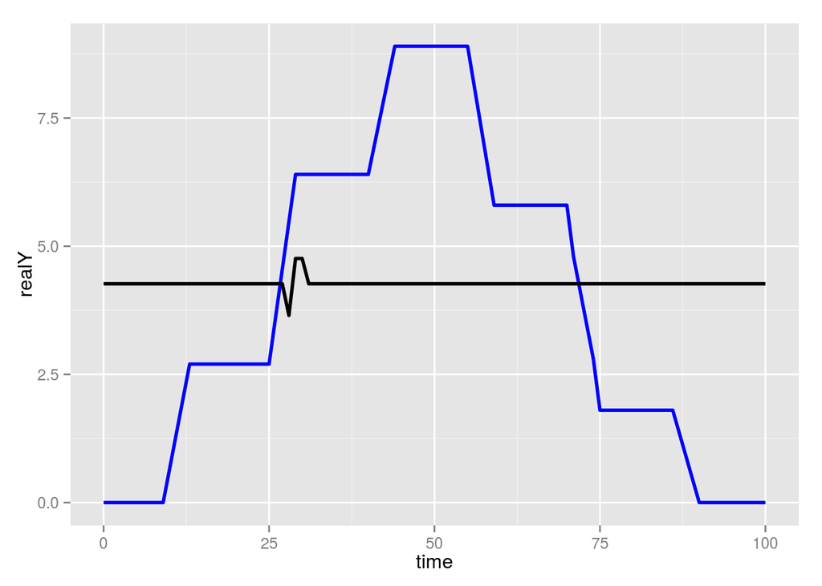

```r
ggplot(pred4, aes(x = time, y = realY)) + geom_line(col="blue",size=1) + geom_line(data=pred4, aes(x=time,y=predY),col="black",size=1)
```

```r
corX <- cor(pred4$realX,pred4$predX)
print(paste("Rsquared X=",corX^2,sep=""))
```

```
## [1] "Rsquared X=0.00274303117584052"
```

```r
corY <- cor(pred4$realY,pred4$predY)
print(paste("Rsquared Y=",corY^2,sep=""))
```

```
## [1] "Rsquared Y=0.00276195360111069"
```

```r
pred4$residual <- sqrt((pred4$realX-pred4$predX)^2 + (pred4$realY-pred4$predY)^2)
print(paste("Overall RMSE=",sqrt(var(pred4$residual, na.rm=T)),sep=""))
```

```
## [1] "Overall RMSE=0.685952223772009"
```

```r
distanceError <- sqrt((pred4$predX - pred4$realX)^2 + (pred4$predY - pred4$realY)^2)
mean(distanceError)
```

```
## [1] 3.68258
```

```r
sd(distanceError)
```

```
## [1] 0.6859522
```

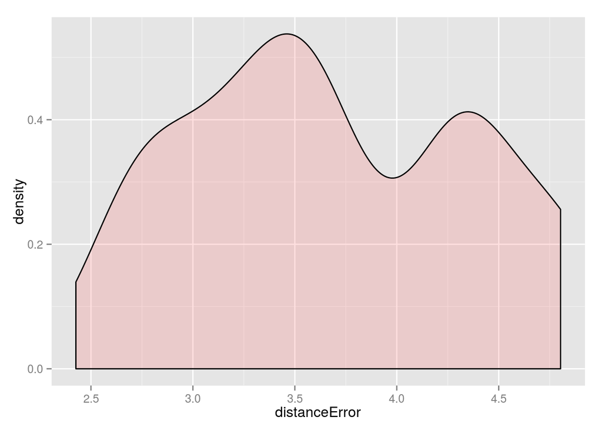

```r
error <- as.data.frame(distanceError)
ggplot(error, aes(x=distanceError)) + geom_density(alpha=.2, fill="#FF6666")
```

# Test walks

## A) Walk with stops through the center of the room (cross pattern)

```
## [1] 30.32442
```

```
## [1] 26.11826
```

```r
pred3$walk <- 1
topred$walk <- 2
newtraindata <- rbind(pred3,topred)
newfitloess <- lm(cbind(realX,realY) ~ loessdistance1*loessdistance2*loessdistance3*loessdistance4*loessdistance5*loessdistance6, data=newtraindata)
summary(newfitloess)
```

```
## Response realX :
##
## Call:
## lm(formula = realX ~ loessdistance1 * loessdistance2 * loessdistance3 *
##     loessdistance4 * loessdistance5 * loessdistance6, data = newtraindata)
##
## Residuals:
##      Min       1Q   Median       3Q      Max
## -1.46415 -0.16344  0.00352  0.17614  1.67943
##
## Coefficients:
##                                                                                             Estimate
## (Intercept)                                                                               -27.247563
## loessdistance1                                                                             14.154005
## loessdistance2                                                                            -11.808098
## loessdistance3                                                                             11.092268
## loessdistance4                                                                             18.029306
## loessdistance5                                                                             15.456908
## loessdistance6                                                                             12.667173
## loessdistance1:loessdistance2                                                               2.137662
## loessdistance1:loessdistance3                                                              -3.354627
## loessdistance2:loessdistance3                                                               5.434496
## loessdistance1:loessdistance4                                                              -8.891808
## loessdistance2:loessdistance4                                                               1.854046
## loessdistance3:loessdistance4                                                              -7.178623
## loessdistance1:loessdistance5                                                              -8.365725
## loessdistance2:loessdistance5                                                               6.107523
## loessdistance3:loessdistance5                                                              -6.737155
## loessdistance4:loessdistance5                                                              -9.760418
## loessdistance1:loessdistance6                                                              -5.893452
## loessdistance2:loessdistance6                                                               3.278589
## loessdistance3:loessdistance6                                                              -6.189878
## loessdistance4:loessdistance6                                                              -8.850877
## loessdistance5:loessdistance6                                                              -5.929234
## loessdistance1:loessdistance2:loessdistance3                                               -1.932776
## loessdistance1:loessdistance2:loessdistance4                                                0.712212
## loessdistance1:loessdistance3:loessdistance4                                                2.643567
## loessdistance2:loessdistance3:loessdistance4                                               -1.328637
## loessdistance1:loessdistance2:loessdistance5                                               -1.391445
## loessdistance1:loessdistance3:loessdistance5                                                2.965846
```

[output cut: 631 more lines]

```
## loessdistance2:loessdistance4:loessdistance5:loessdistance6                               *
## loessdistance3:loessdistance4:loessdistance5:loessdistance6                               *
## loessdistance1:loessdistance2:loessdistance3:loessdistance4:loessdistance5
## loessdistance1:loessdistance2:loessdistance3:loessdistance4:loessdistance6
## loessdistance1:loessdistance2:loessdistance3:loessdistance5:loessdistance6
## loessdistance1:loessdistance2:loessdistance4:loessdistance5:loessdistance6                *
## loessdistance1:loessdistance3:loessdistance4:loessdistance5:loessdistance6
## loessdistance2:loessdistance3:loessdistance4:loessdistance5:loessdistance6
## loessdistance1:loessdistance2:loessdistance3:loessdistance4:loessdistance5:loessdistance6
## ---
## Signif. codes:  0 '***' 0.001 '**' 0.01 '*' 0.05 '.' 0.1 ' ' 1
##
## Residual standard error: 0.915 on 116 degrees of freedom
## Multiple R-squared:  0.9301, Adjusted R-squared:  0.8921
## F-statistic:  24.5 on 63 and 116 DF,  p-value: < 2.2e-16
```

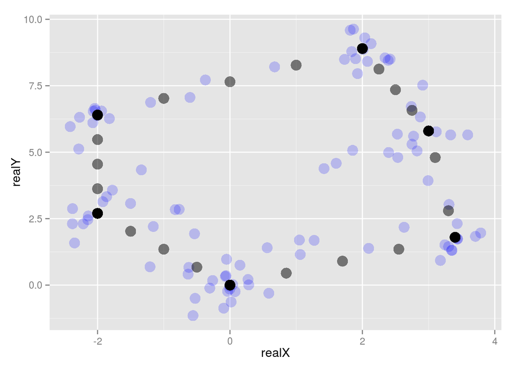

```r
predictions <- predict(newfitloess, newdata=newtraindata)

#We plot the predictions
# count=0
# for(i in pred3$time){
#     count <- count+1
#     plot(beacons$beaconX,beacons$beaconY,xlim=c(-10,11),ylim=c(-8,17))
#
#     subset <- df[round(df$reltime/1000)==i,]
#     points(subset$realX,subset$realY, pch="x", cex=2)
#     for(beacon in beacons$beaconID){
#         draw.circle(beacons[beacons$beaconID==beacon,"beaconX"],beacons[beacons$beaconID==beacon,"beaconY"],radius=subset[subset$beaconID==beacon,"distance"],border="blue")
#     }
#     points(predictions[count,"realX"],predictions[count,"realY"], pch="o", cex=2)
#     cat ("Press [enter] to continue")
#     line <- readline()
# }
# for(i in topred$time){
#     count <- count+1
#     plot(beacons$beaconX,beacons$beaconY,xlim=c(-10,11),ylim=c(-8,17))
#
#     subset <- df2[round(df2$reltime/1000)==i,]
#     points(subset$realX,subset$realY, pch="x", cex=2)
#     for(beacon in beacons$beaconID){
#         draw.circle(beacons[beacons$beaconID==beacon,"beaconX"],beacons[beacons$beaconID==beacon,"beaconY"],radius=subset[subset$beaconID==beacon,"distance"],border="blue")
#     }
#     points(predictions[count,"realX"],predictions[count,"realY"], pch="o", cex=2)
#     cat ("Press [enter] to continue")
#     line <- readline()
# }

# Scatterplot comparison of prediction and real
ggplot(data.frame(predictions)[1:97,], aes(x = realX, y = realY)) + geom_point(alpha=0.2,col="blue",size=5) + geom_point(data=pred3,alpha=0.5,col="black",size=5)
```

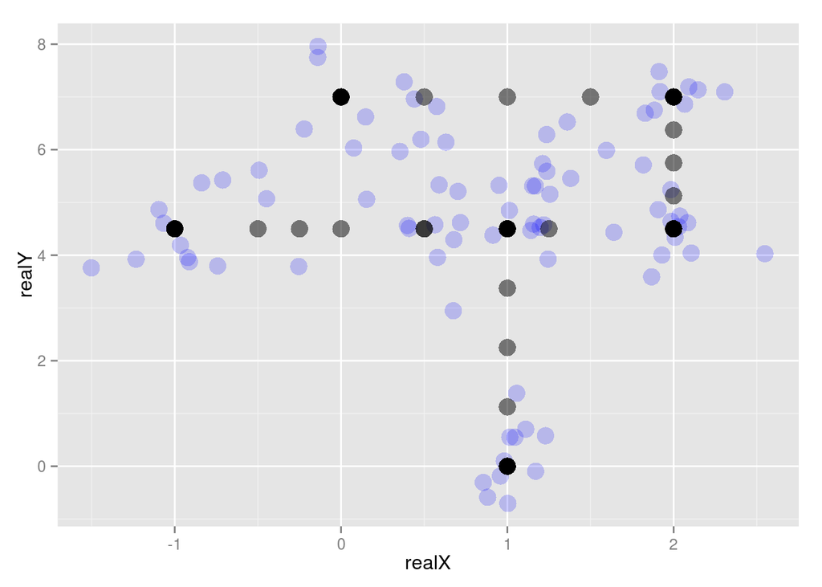

```r
ggplot(data.frame(predictions)[98:180,], aes(x = realX, y = realY)) + geom_point(alpha=0.2,col="blue",size=5) + geom_point(data=topred,alpha=0.5,col="black",size=5)
```

```r
newtraindata$predX <- predictions[,1]
newtraindata$predY <- predictions[,2]

distanceError <- sqrt((newtraindata$predX - newtraindata$realX)^2 + (newtraindata$predY - newtraindata$realY)^2)
mean(distanceError)
```

```
## [1] 0.6679967
```

```r
sd(distanceError)
```

```
## [1] 0.5104245
```

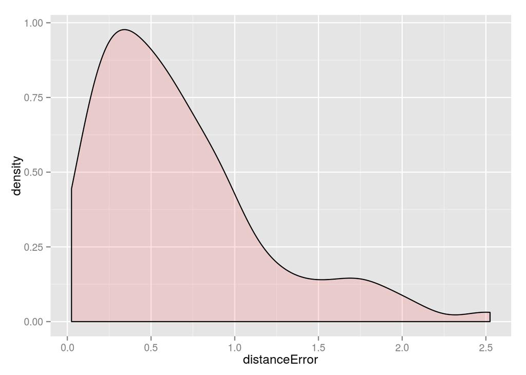

```r
error <- as.data.frame(distanceError)
ggplot(error, aes(x=distanceError)) + geom_density(alpha=.2, fill="#FF6666")
```

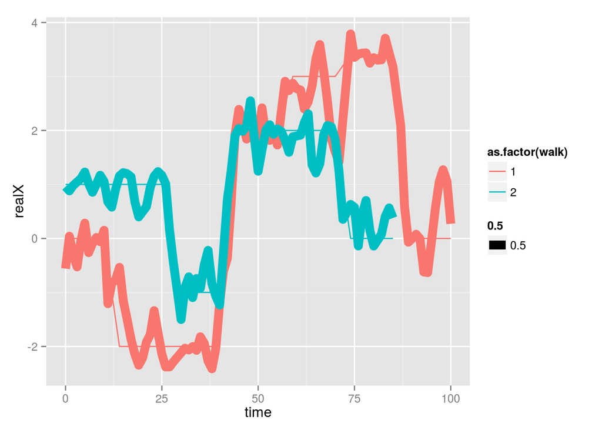

```r
# plot realX and predX over time
ggplot(newtraindata,aes(x=time,y=realX,color=as.factor(walk)))+geom_line()+geom_line(aes(x=time,y=predX,color=as.factor(walk),size=0.5))
```

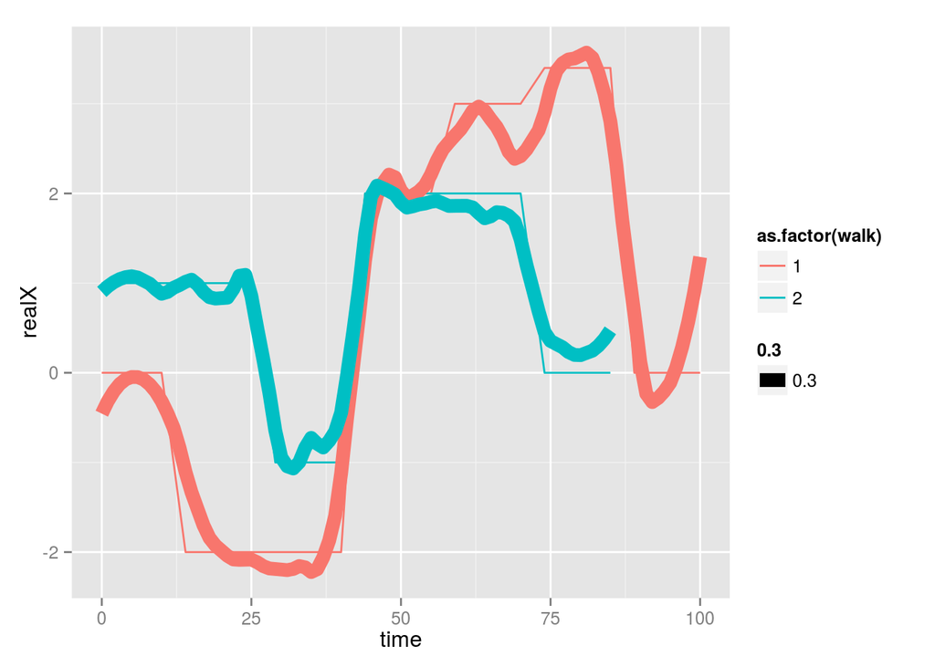

```r
# What if we re-smooth the predicted values?
# Split the data into walks before doing the smoothing!
finaldata <- data.frame()
for(i in unique(newtraindata$walk)){
    data <- newtraindata[newtraindata$walk==i,]
    loessX <- loess(predX~time,data,span=0.2)#After several tries, this seems to be the best smoothing value!
    loessY <- loess(predY~time,data,span=0.2)
    data$predX2 <- predict(loessX,newdata=data)
    data$predY2 <- predict(loessY,newdata=data)
    finaldata <- rbind(finaldata,data)
}

# We plot the new predicted values again
ggplot(finaldata,aes(x=time,y=realX,color=as.factor(walk)))+geom_line()+geom_line(aes(x=time,y=predX2,color=as.factor(walk),size=0.3))
```

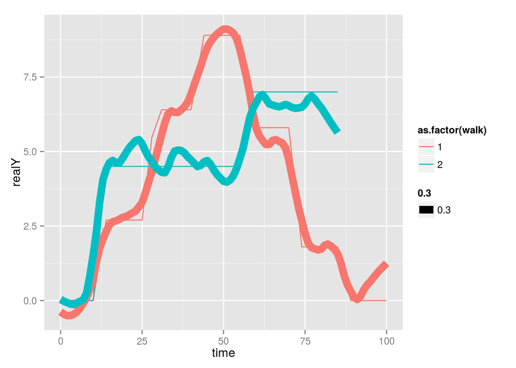

```r
ggplot(finaldata,aes(x=time,y=realY,color=as.factor(walk)))+geom_line()+geom_line(aes(x=time,y=predY2,color=as.factor(walk),size=0.3))
```

```r
#    line <- readline()
#    cat ("Press [enter] to continue")

distanceError <- sqrt((finaldata$predX2 - finaldata$realX)^2 + (finaldata$predY2 - finaldata$realY)^2)
mean(distanceError)
```

```
## [1] 0.4519289
```

```r
sd(distanceError)
```

```
## [1] 0.3302441
```

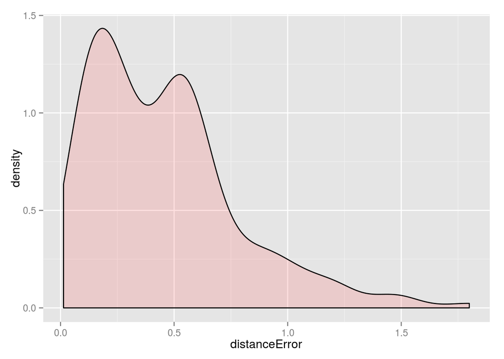

```r
# We plot the density distribution of error
error <- as.data.frame(distanceError)
ggplot(error, aes(x=distanceError)) + geom_density(alpha=.2, fill="#FF6666")
```